# Translation Elicitation

30/07/2020

# Behavioural task

## Sample

107 participants (mean age = 21.79, *SD* age = 2.41, age range = 18-33).

74 participants were British English native speakers living in United Kingdom (49 female), and 33 participants were Spanish native speakers living in Spain (28 female).

Exclusion criteria:

1. Oral and/or written skills in a second or third language as higher than 4 in a 5-point scale (*n* = 1)
2. Language impairment (*n* = 2)[^1]
3. Did not contribute more than 80% of valid trials (*n* = 9)

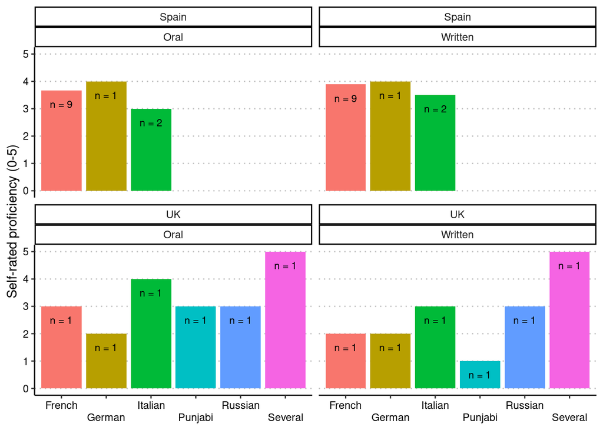

Second languages. Some participants reported being familiar with one or more langugaes other than English (for UK participants) or Spanish (for participants in Spain). We asked them to self-report their oral and written proficiency in those languages in a 0-to-5 scale. This graph shows the mean proficiency reported by participants that reported being familiar with each language. the number of participants that reported being familiar with each language is reported on top of each bar. Data are presented for UK and Spanish participants separately.

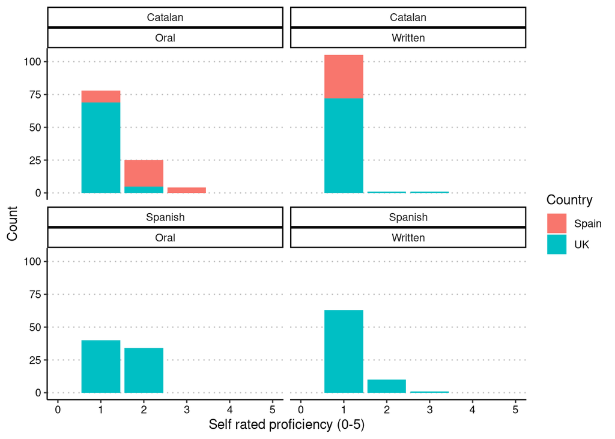

We also asked participants to rate their oral and written proficiency in the target languages (Spanish and Catalan). UK participants were aked about Spanish and Catalan while Spanish participants were aonly asked about Catalan. The graph represents how many participants (self-) reported each levels of proficiency (0-5). Data are presented separately for UK and Spanish participants.

## Design

- 0 - 1000 ms: fixation point
- 1000 - 2500 ms: audio
- 2500 ms - Press RETURN key: type response

## Stimuli

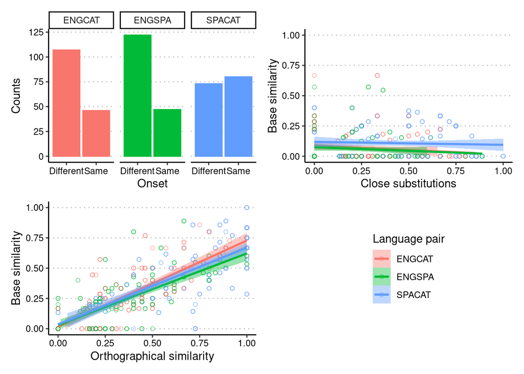

Distribution of trial words from the three groups accross different levels of the predictors.

## Data analysis

We fit Bayesian logistic models to model the probability of participants typing a correct translation in each trial. As predictors, we included:

- *PTHN*: the number of more frequent phonological neighbours of the translation (`PTHN`, standardised)
- *Onset*: do both translation equivalents start with the same phoneme? (`same_onset`, with levels `Different`, and `Same`, sum-coded as `different` (-0.5) vs. `same` (0.5)
- *Close substitutions*: proportion of phoneme matches differing by 1 level on 1 feature (`close_substitutions`, standardised).
- *Base similarity*: Proportion of phoneme matches with identical codes (`similarity_phon`, standardised).

We first for a null model `fit1_pthn` that only included PTHN as predictor. We then extended the model by fitting three other models that included one of the predictors of interest (*Onset*, *Close substitutions*, or *Base similarity*) in interaction with *PTHN*. Finally, we fitted a model that included the traditional orthographical Levenshtein similarity (`similarity_ort`, standardised) to test whether our phonology-based measure predicted participants responses better than just relying on orthography. The models included a maximal random-effects structure (with random intercepts and slopes for all fixed effects) and were implemented in the `brms` R package using the following formulas:

- `fit1_pthn <- correct | trials(total) ~ pthn + (1 + pthn | group)`
- `fit2_onset <- correct | trials(total) ~ pthn*same_onset + (1 + pthn*same_onset | group)`
- `fit3_close <- correct | trials(total) ~ pthn*close_substitutions + (1 + pthn*close_substitutions | group)`
- `fit4_phon <- correct | trials(total) ~ pthn*similarity_phon + (1 + pthn*similarity_phon | group)`
- `fit5_ort <- correct | trials(total) ~ pthn*similarity_ort + (1 + pthn*similarity_ort | group)`